River A. Watson

## Example 1

We’re gonna look at what influences the genetic fixation/isolation in Kentucky Arrow Darter populations

```r
KADdata
```

```
##    Pop pFst sCulvert Condb pForest distmi
## 1  1-2 0.20    0.380 373.0      90  16.42
## 2  1-3 0.11    0.160 254.0      90   4.20
## 3  1-4 0.40    0.802 181.0      60  35.00
## 4  1-5 0.30    0.907 338.0      85  11.00
## 5  2-3 0.34    0.160 412.0      90  18.59
## 6  2-4 0.13    0.802 280.0      60  56.22
## 7  2-5 0.30    0.907 476.0      90   5.50
## 8  3-4 0.40    0.962 181.0      60  37.63
## 9  3-5 0.40    1.065 380.0      90  13.00
## 10 4-5 0.30    1.710 247.9      60  50.00
```

Any correlation?

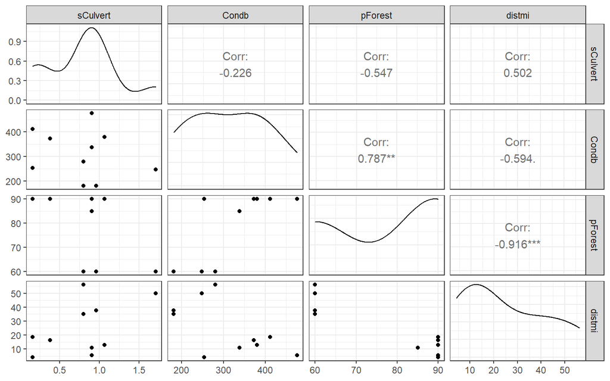

```r
ggpairs(KADdata, columns = 3:6) + theme_bw()
```

```r
model_kad <- lm(pFst ~ sCulvert + Condb + pForest + distmi, data=KADdata)
anova (model_kad)
```

```
## Analysis of Variance Table
##
## Response: pFst
##           Df   Sum Sq   Mean Sq F value Pr(>F)
## sCulvert   1 0.016475 0.0164745  1.1370 0.3351
## Condb      1 0.000159 0.0001586  0.0109 0.9207
## pForest    1 0.000329 0.0003289  0.0227 0.8861
## distmi     1 0.015748 0.0157485  1.0869 0.3449
## Residuals  5 0.072450 0.0144899
```

No significant variables, good start

Check for multicollinearity

```r
performance::check_collinearity(model_kad)
```

```
## # Check for Multicollinearity
##
## Low Correlation
##
##      Term  VIF Increased SE Tolerance
##  sCulvert 1.81         1.35      0.55
##     Condb 4.62         2.15      0.22
##
## Moderate Correlation
##
##    Term  VIF Increased SE Tolerance
##  distmi 9.10         3.02      0.11
##
## High Correlation
##
##     Term   VIF Increased SE Tolerance
##  pForest 19.54         4.42      0.05
```

Apparently, percent forest cover and river distance between sites are not important to keep. They data they provide to the model is already accurately predicted by the other variables.

Dredging is bad, but all of these variables have a reason for being biologically significant

```r
options(na.action = 'na.fail')
dredge_kad <- dredge(model_kad)
dredge_kad
```

```
## Global model call: lm(formula = pFst ~ sCulvert + Condb + pForest + distmi, data = KADdata)
## ---
## Model selection table
##    (Intrc)      Condb      distm      pFrst   sClvr df logLik  AICc delta
## 1   0.2880                                           2  8.585 -11.5  0.00
## 9   0.2156                                  0.09213  3  9.437  -8.9  2.58
## 5   0.3782                       -0.0011640          3  8.719  -7.4  4.02
## 2   0.3056 -5.641e-05                                3  8.598  -7.2  4.26
## 3   0.2858             8.954e-05                     3  8.586  -7.2  4.28
## 11  0.2283            -1.420e-03            0.12070  4  9.710  -3.4  8.04
## 13  0.1656                        0.0005470 0.10190  4  9.461  -2.9  8.53
## 10  0.2004  4.340e-05                       0.09423  4  9.446  -2.9  8.56
## 7   0.9192            -4.824e-03 -0.0066040          4  9.327  -2.7  8.80
## 6   0.3974  2.189e-04            -0.0022940          4  8.799  -1.6  9.86
## 4   0.3138 -7.178e-05 -1.378e-04                     4  8.600  -1.2 10.26
```

[output cut: 23 more lines]

16 whole models

```r
subset(dredge_kad, delta <5)
```

```
## Global model call: lm(formula = pFst ~ sCulvert + Condb + pForest + distmi, data = KADdata)
## ---
## Model selection table
##   (Intrc)      Condb     distm     pFrst   sClvr df logLik  AICc delta weight
## 1  0.2880                                         2  8.585 -11.5  0.00  0.608
## 9  0.2156                                0.09213  3  9.437  -8.9  2.58  0.167
## 5  0.3782                      -0.001164          3  8.719  -7.4  4.02  0.082
## 2  0.3056 -5.641e-05                              3  8.598  -7.2  4.26  0.072
## 3  0.2858            8.954e-05                    3  8.586  -7.2  4.28  0.071
## Models ranked by AICc(x)
```

Down to 5 models with a delta value less than 5

```r
subset(dredge_kad, delta <2)
```

```
## Global model call: lm(formula = pFst ~ sCulvert + Condb + pForest + distmi, data = KADdata)
## ---
## Model selection table
##   (Intrc) df logLik  AICc delta weight
## 1   0.288  2  8.585 -11.5     0      1
## Models ranked by AICc(x)
```

Just one with a delta less than two, none are considered equally competitive

```r
importance(dredge_kad)
```

```
##                      sCulvert pForest distmi Condb
## Sum of weights:      0.187    0.098   0.090  0.085
## N containing models:     8        8       8      8
```

All variables appear in half of the provide models. None of them really have any importance, no weights are close to 1

Model averaging based on weights in all 16 models

```r
model.avg(dredge_kad, revised.var = TRUE)
```

```
##
## Call:
## model.avg(object = dredge_kad, revised.var = TRUE)
##
## Component models:
## '(Null)' '4'      '3'      '1'      '2'      '24'     '34'     '14'
## '23'     '13'     '12'     '234'    '123'    '124'    '134'    '1234'
##
## Coefficients:
##        (Intercept)   sCulvert       pForest         Condb        distmi
## full     0.2874896 0.01764801 -0.0001463378 -2.785605e-06 -4.609113e-05
## subset   0.2874896 0.09428327 -0.0014918209 -3.265438e-05 -5.125866e-04
```

All variables have little overall effect

Looking only at competitive models, with a delta less than three

```r
summary(model.avg(dredge_kad, subset = delta < 3))
```

```
##
## Call:
## model.avg(object = dredge_kad, subset = delta < 3)
##
## Component model call:
## lm(formula = pFst ~ <2 unique rhs>, data = KADdata)
##
## Component models:
##        df logLik   AICc delta weight
## (Null)  2   8.58 -11.46  0.00   0.78
## 1       3   9.44  -8.87  2.58   0.22
##
## Term codes:
## sCulvert
##        1
##
## Model-averaged coefficients:
## (full average)
##             Estimate Std. Error Adjusted SE z value Pr(>|z|)
## (Intercept)  0.27239    0.05293     0.05908   4.611    4e-06 ***
## sCulvert     0.01987    0.05165     0.05605   0.355    0.723
##
## (conditional average)
##             Estimate Std. Error Adjusted SE z value Pr(>|z|)
## (Intercept)  0.27239    0.05293     0.05908   4.611 4.01e-06 ***
## sCulvert     0.09213    0.07557     0.08892   1.036      0.3
## ---
## Signif. codes:  0 '***' 0.001 '**' 0.01 '*' 0.05 '.' 0.1 ' ' 1
```

Models with a delta less than three only take culvert score into account

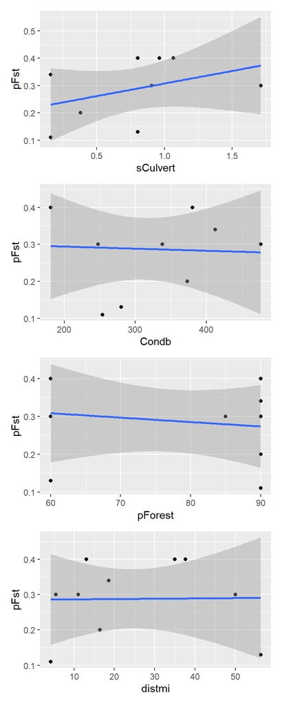

```r
k1 <- ggplot(KADdata, aes(sCulvert, pFst)) +
  geom_point() +
  geom_smooth(method="lm")

k2 <- ggplot(KADdata, aes(Condb, pFst)) +
  geom_point() +
  geom_smooth(method="lm")

k3 <- ggplot(KADdata, aes(pForest, pFst)) +
  geom_point() +
  geom_smooth(method="lm")

k4 <- ggplot(KADdata, aes(distmi, pFst)) +
  geom_point() +
  geom_smooth(method="lm")


k1 / k2 / k3 / k4
```

## Example 2

Data about fish abundance and culverts

First we must acknowledge my favorite locality information:

```r
data <- read.csv('data/WeyData.csv')
data[,6:7] <- round(data[,6:7],3)
data[,3:8]
```

```
##    Abundance                    Type Height Velocity Water_Dept Pool_Depth
## 1         73                    Weir   1.58    0.650      0.450       1.42
## 2        151                  Sluice   1.60    0.100      0.100       0.30
## 3          6                 Culvert   0.56    0.500      0.450       1.20
## 4         47 Vertical & sloping weir   1.50    2.000      0.234       0.70
## 5         72                  Sluice   2.74    0.200      0.660       1.28
## 6          8                    Weir   0.86    1.000      1.000       1.21
## 7         85           Vertical weir   0.30    1.500      0.450       0.95
## 8         31              Notch weir   1.50    1.300      0.500       1.00
## 9          3            Stepped weir   1.30    1.200      0.890       1.58
## 10        57                  Bridge   0.10    0.200      0.590       3.00
## 11         0                 Culvert   2.00    0.160      0.256       0.56
## 12       241                    Ford   0.00    0.150      0.350       0.65
## 13        54                    Weir   0.55    0.661      0.430       0.99
## 14         0                    Weir   0.84    1.200      0.300       0.67
```

[output cut: 25 more lines]

Any correlations?

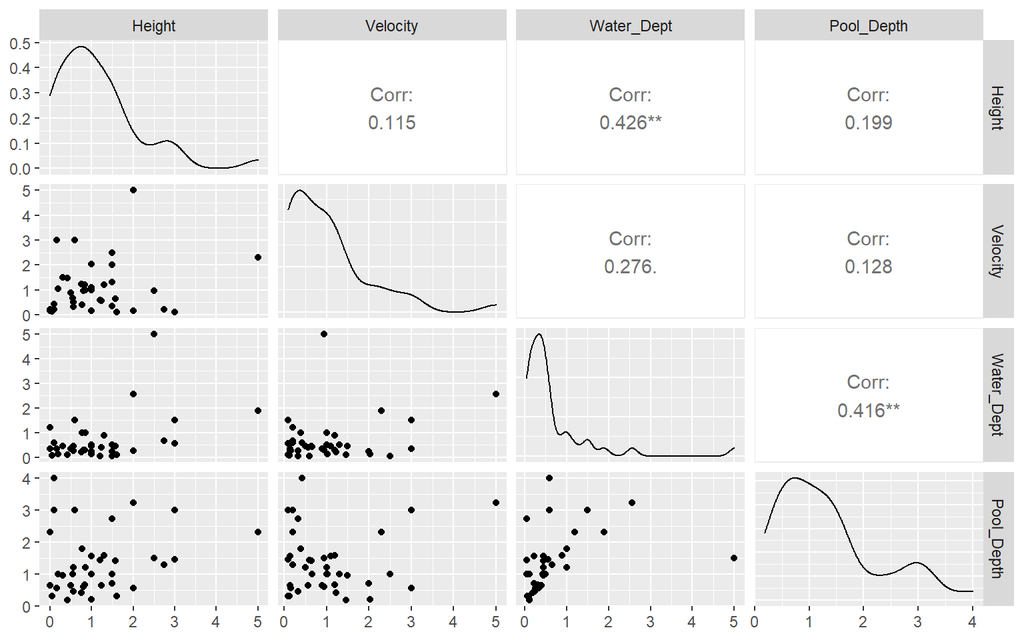

```r
ggpairs(data[,5:8], lower.panel = NULL)
```

Make some models

```r
options(na.action = "na.fail")
mod1<-lm(Abundance~Water_Dept+Velocity, data = data)
mod2<-lm(Abundance~Water_Dept+Pool_Depth, data = data)
mod3<-lm(Abundance~Velocity+Pool_Depth, data = data)
mod4<-lm(Abundance~Height+Velocity+Water_Dept, data = data)
mod5<-lm(Abundance~Height+Velocity+Water_Dept+Pool_Depth, data = data)
```

4 variables, 5 models

Compare models AICcs

```r
out.put<-model.sel(mod1,mod2,mod3,mod4,mod5)
out.put
```

```
## Model selection table
##      (Int)   Vlc Wtr_Dept Pol_Dpth    Hgh             family df   logLik  AICc
## mod3 72.93 6.262            -6.523        gaussian(identity)  4 -219.984 449.1
## mod1 67.07 6.683  -4.9850                 gaussian(identity)  4 -220.063 449.3
## mod2 78.34        -0.4443   -5.477        gaussian(identity)  4 -220.150 449.5
## mod4 78.14 6.653   1.4840          -13.23 gaussian(identity)  5 -219.438 450.7
## mod5 83.44 6.725   3.7030   -5.221 -13.10 gaussian(identity)  6 -219.352 453.3
##      delta weight
## mod3  0.00  0.298
## mod1  0.16  0.275
## mod2  0.33  0.252
## mod4  1.55  0.137
## mod5  4.19  0.037
## Models ranked by AICc(x)
```

Model3, using Velocity and Pool depth is most likely the best explanation for differences in fish abundance at barriers, but model 1 and 2 are very close behind it. All delta values are less than 5.

Cut down the list using cumulitive weight criteria

```r
subset(out.put, cumsum(out.put$weight) <= .95)
```

```
## Model selection table
##      (Int)   Vlc Wtr_Dept Pol_Dpth             family df   logLik  AICc delta
## mod3 72.93 6.262            -6.523 gaussian(identity)  4 -219.984 449.1  0.00
## mod1 67.07 6.683  -4.9850          gaussian(identity)  4 -220.063 449.3  0.16
## mod2 78.34        -0.4443   -5.477 gaussian(identity)  4 -220.150 449.5  0.33
##      weight
## mod3  0.361
## mod1  0.333
## mod2  0.306
## Models ranked by AICc(x)
```

Make the table prettier

```r
sel.table<-as.data.frame(out.put)[7:11]
names(sel.table)[1] = "K"

sel.table[,2:3]<- round(sel.table[,2:3],2)
sel.table[,4:5]<- round(sel.table[,4:5],3)
sel.table
```

```
##      K  logLik   AICc delta weight
## mod3 4 -219.98 449.14 0.000  0.298
## mod1 4 -220.06 449.30 0.159  0.275
## mod2 4 -220.15 449.48 0.332  0.252
## mod4 5 -219.44 450.69 1.550  0.137
## mod5 6 -219.35 453.33 4.185  0.037
```

model averaging

```r
MA.ests<-model.avg(out.put, revised.var = TRUE)
MA.ests
```

```
##
## Call:
## model.avg(object = out.put, revised.var = TRUE)
##
## Component models:
## '13'   '12'   '23'   '124'  '1234'
##
## Coefficients:
##        (Intercept) Velocity Pool_Depth Water_Dept    Height
## full       73.7844 4.867726  -3.519161  -1.144933  -2.29795
## subset     73.7844 6.511602  -5.991927  -1.631177 -13.20055
```

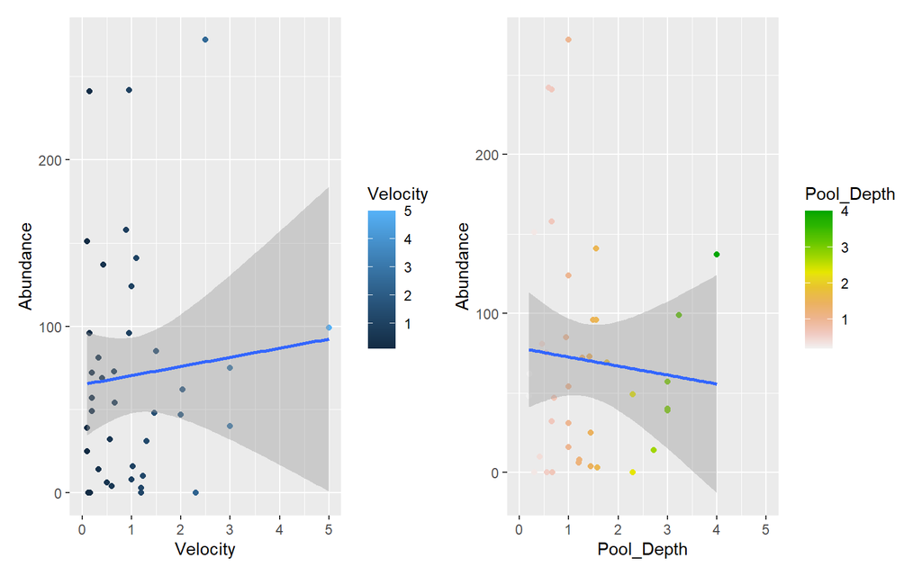

```r
p1 <- ggplot(data, aes(Velocity, Abundance, colour = Velocity)) +
  geom_point() +
  geom_smooth(method="lm")+
  scale_x_continuous(limits = c(0, 5))

p2 <- ggplot(data, aes(Pool_Depth, Abundance, colour = Pool_Depth)) +
  geom_point() +
  geom_smooth(method="lm") +
  scale_colour_gradientn(colours = terrain.colors(10, rev=TRUE)) +
  scale_x_continuous(limits = c(0, 5))

p1+p2
```